# Random Forest Experiments Using Trunk and Parity Datasets

James Browne

November 22, 2016

===============================================================================

##### Classifier- RF

- mtry = mdim^.5
- 500 trees

```
## average time per iteration-  1.321  seconds
```

```
##    Min. 1st Qu.  Median    Mean 3rd Qu.    Max.
##   5.840   5.920   6.000   5.953   6.010   6.020
```

===============================================================================

##### Classifier- RF

- mtry = mdim^.5
- 1000 trees

```
## average time per iteration-  2.428  seconds
```

```
##    Min. 1st Qu.  Median    Mean 3rd Qu.    Max.
##   5.850   5.895   5.940   5.917   5.950   5.960
```

=============================================================================

##### Classifier- RerF

- A is mdim by mdim
- Sparse A: mdim non zero entries all of which have 50/50 chance of being 1/-1.
- 500 trees
- mtry = mdim^.5

```
## average time per iteration-  2.478  seconds
```

```
##    Min. 1st Qu.  Median    Mean 3rd Qu.    Max.
##   4.820   4.835   4.850   4.850   4.865   4.880
```

===============================================================================

##### Classifier- RerF

- A is mdim by mdim
- Sparse A: mdim non zero entries all of which have 50/50 chance of being 1/-1.
- 1000 trees
- mtry = mdim^.5

```
## average time per iteration-  4.76666666666667  seconds
```

```
##    Min. 1st Qu.  Median    Mean 3rd Qu.    Max.
##   4.830   4.860   4.890   4.877   4.900   4.910
```

===============================================================================

##### Classifier- RerF

- A is mdim by mdim
- Sparse A: mdim non zero entries all of which have 50/50 chance of being 1/-1.
- 2000 trees
- mtry = mdim^.5

```
## average time per iteration-  9.453  seconds
```

```
##    Min. 1st Qu.  Median    Mean 3rd Qu.    Max.
##   4.820   4.865   4.910   4.880   4.910   4.910
```

=============================================================================

##### Classifier- RerF

- A is mdim by mtry
- Sparse A: mdim non zero entries all of which have 50/50 chance of being 1/-1.
- 500 trees
- mtry = mdim^.5

```
## average time per iteration-  1.447  seconds
```

```
##    Min. 1st Qu.  Median    Mean 3rd Qu.    Max.
##   4.730   4.735   4.740   4.747   4.755   4.770
```

===============================================================================

##### Classifier- RerF

- A is mdim by mtry
- Sparse A: mdim non zero entries all of which have 50/50 chance of being 1/-1.
- 1000 trees
- mtry = mdim^.5

```
## average time per iteration-  2.90833333333333  seconds
```

```
##    Min. 1st Qu.  Median    Mean 3rd Qu.    Max.
##   4.700   4.730   4.760   4.743   4.765   4.770
```

===============================================================================

##### Classifier- RerF

- A is mdim by mtry
- Sparse A: mdim non zero entries all of which have 50/50 chance of being 1/-1.
- 2000 trees
- mtry = mdim^.5

```
## average time per iteration-  5.851  seconds
```

```
##    Min. 1st Qu.  Median    Mean 3rd Qu.    Max.
##   4.650   4.655   4.660   4.677   4.690   4.720
```

===============================================================================

##### Classifier- XGBoost

- num_rounds = 1
- 500 trees

```
## here in 1here in 2obj is null[1] train-merror:0.032000
## here in 1here in 2obj is null[1] train-merror:0.033000
## here in 1here in 2obj is null[1] train-merror:0.031000
```

```
## average time per iteration-  0.766000000000001  seconds
```

```
##    Min. 1st Qu.  Median    Mean 3rd Qu.    Max.
##   5.970   6.010   6.050   6.033   6.065   6.080
```

=================================================================================

##### Classifier- XGBoost

- num_rounds = 6
- 500 trees

```
## here in 1here in 2obj is null[1] train-merror:0.029000
## here in 1here in 2obj is null[2] train-merror:0.029000
## here in 1here in 2obj is null[3] train-merror:0.028000
## here in 1here in 2obj is null[4] train-merror:0.026000
## here in 1here in 2obj is null[5] train-merror:0.025000
## here in 1here in 2obj is null[6] train-merror:0.023000
## here in 1here in 2obj is null[1] train-merror:0.030000
## here in 1here in 2obj is null[2] train-merror:0.030000
## here in 1here in 2obj is null[3] train-merror:0.027000
## here in 1here in 2obj is null[4] train-merror:0.026000
## here in 1here in 2obj is null[5] train-merror:0.026000
## here in 1here in 2obj is null[6] train-merror:0.024000
## here in 1here in 2obj is null[1] train-merror:0.029000
## here in 1here in 2obj is null[2] train-merror:0.027000
## here in 1here in 2obj is null[3] train-merror:0.026000
## here in 1here in 2obj is null[4] train-merror:0.027000
## here in 1here in 2obj is null[5] train-merror:0.025000
## here in 1here in 2obj is null[6] train-merror:0.023000
```

```
## average time per iteration-  10.27  seconds
```

```
##    Min. 1st Qu.  Median    Mean 3rd Qu.    Max.
##   6.380   6.385   6.390   6.387   6.390   6.390
```

===============================================================================

===============================================================================

##### Classifier- RF

- mtry = mdim^.5
- 500 trees

```
## average time per iteration-  0.683000000000002  seconds
```

```
##    Min. 1st Qu.  Median    Mean 3rd Qu.    Max.
##   32.00   34.00   36.00   35.33   37.00   38.00
```

===============================================================================

##### Classifier- RF

- mtry = mdim^.5
- 1000 trees

```
## average time per iteration-  1.27  seconds
```

```
##    Min. 1st Qu.  Median    Mean 3rd Qu.    Max.
##    34.0    34.5    35.0    35.0    35.5    36.0
```

===============================================================================

##### Classifier- RerF

- A is mdim by mdim
- Sparse A: mdim non zero entries all of which have 50/50 chance of being 1/-1.
- 500 trees
- mtry = mdim^.5

```
## average time per iteration-  0.359666666666669  seconds
```

```
##    Min. 1st Qu.  Median    Mean 3rd Qu.    Max.
##   45.43   45.76   46.09   45.94   46.20   46.31
```

===============================================================================

##### Classifier- RerF

- A is mdim by mdim
- Sparse A: mdim non zero entries all of which have 50/50 chance of being 1/-1.
- 1000 trees
- mtry = mdim^.5

```
## average time per iteration-  0.680666666666667  seconds
```

```
##    Min. 1st Qu.  Median    Mean 3rd Qu.    Max.
##   46.10   46.26   46.42   46.46   46.64   46.85
```

===============================================================================

##### Classifier- RerF

- A is mdim by mtry
- Sparse A: mdim non zero entries all of which have 50/50 chance of being 1/-1.
- 500 trees
- mtry = mdim^.5

```
## average time per iteration-  0.352999999999999  seconds
```

```
##    Min. 1st Qu.  Median    Mean 3rd Qu.    Max.
##   22.88   22.95   23.02   23.01   23.08   23.14
```

```
## total time-  137.303  seconds
```

===============================================================================

##### Classifier- RerF

- A is mdim by mtry
- Sparse A: mdim non zero entries all of which have 50/50 chance of being 1/-1.
- 1000 trees
- mtry = mdim^.5

```
## average time per iteration-  0.683333333333337  seconds
```

```
##    Min. 1st Qu.  Median    Mean 3rd Qu.    Max.
##   22.65   22.66   22.67   22.74   22.78   22.89
```

```
## total time-  138.398  seconds
```

===============================================================================

##### Classifier- XGBoost

- num_rounds = 1
- 500 trees

```
## here in 1here in 2obj is null[1] train-merror:0.200000
## here in 1here in 2obj is null[1] train-merror:0.170000
## here in 1here in 2obj is null[1] train-merror:0.200000
```

```
## average time per iteration-  0.309333333333332  seconds
```

```
##    Min. 1st Qu.  Median    Mean 3rd Qu.    Max.
##   50.32   50.41   50.50   50.46   50.52   50.55
```

=================================================================================

##### Classifier- XGBoost

- num_rounds = 6
- 500 trees

[output not shown]

```
## average time per iteration-  9.688  seconds
```

```
##    Min. 1st Qu.  Median    Mean 3rd Qu.    Max.
##   49.11   49.11   49.11   49.11   49.11   49.11
```

===============================================================================

##### Classifier- RerF

- A is mdim by mdim

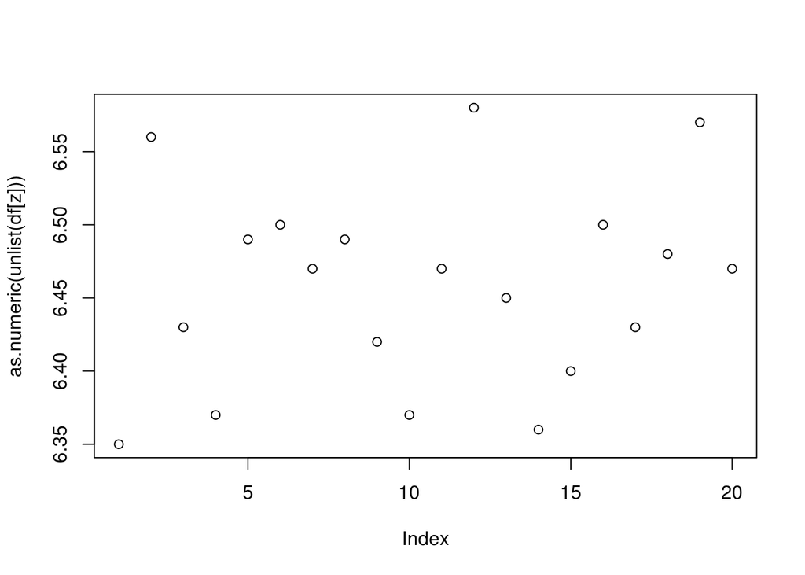

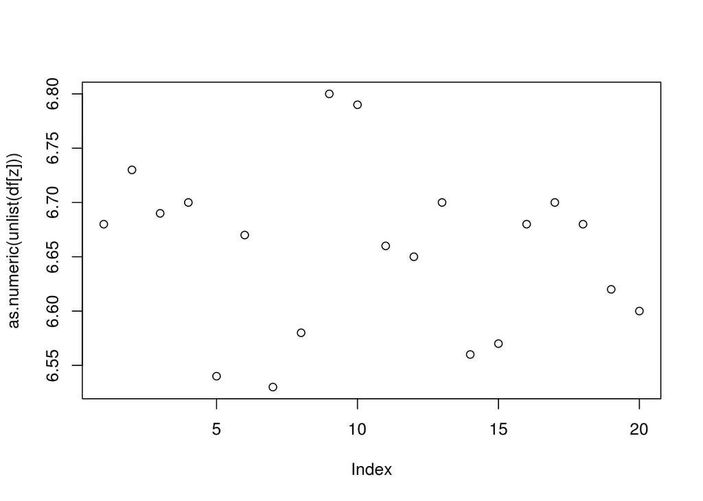

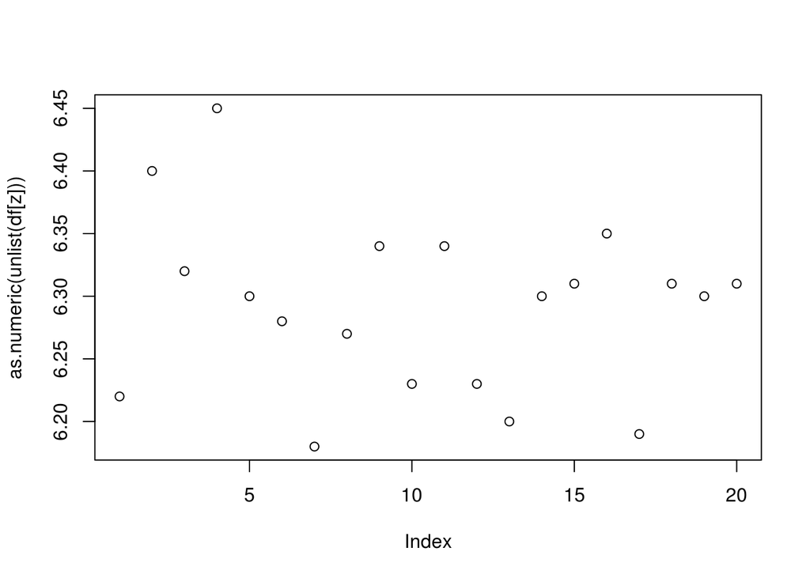

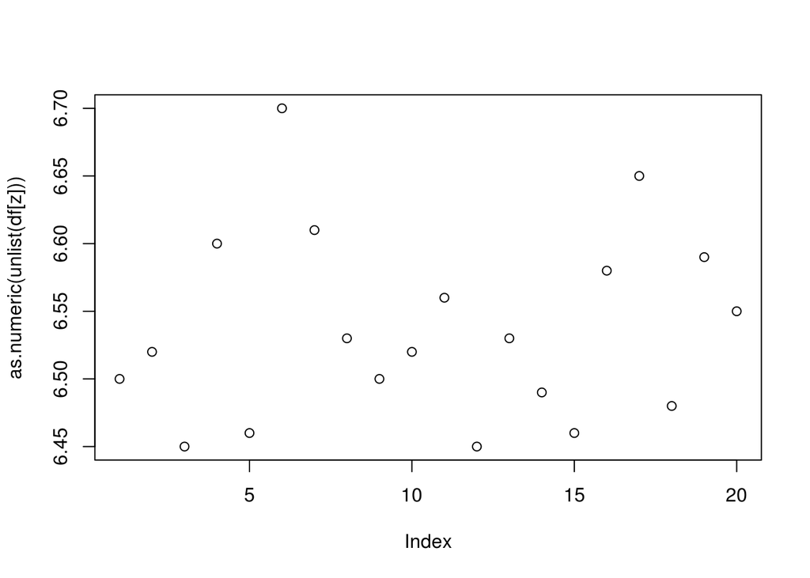

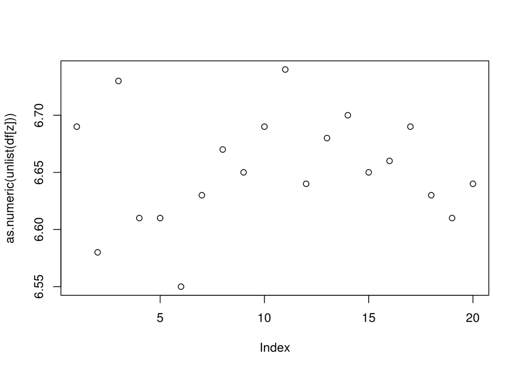

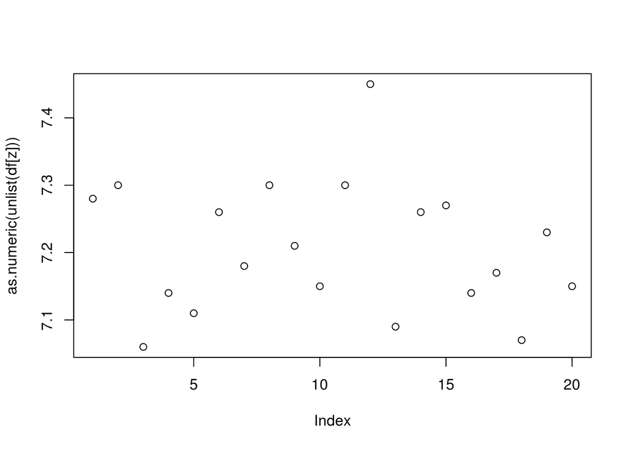

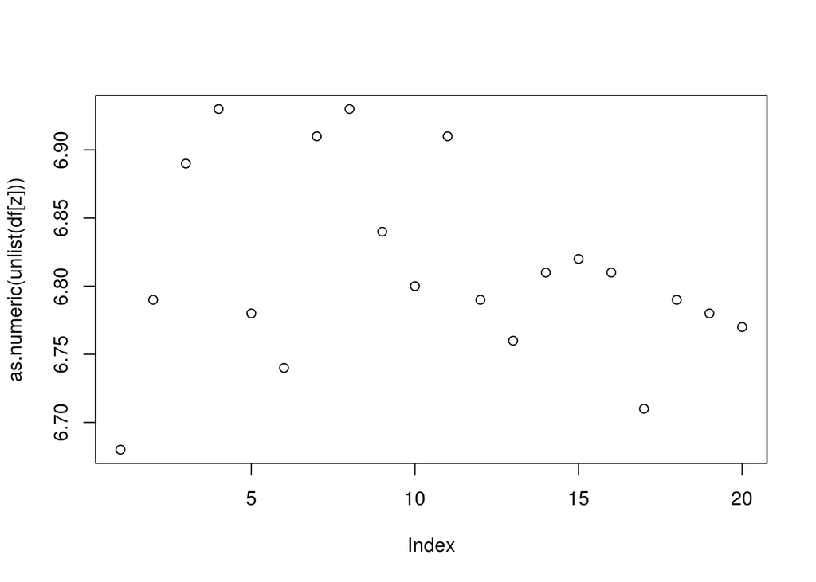

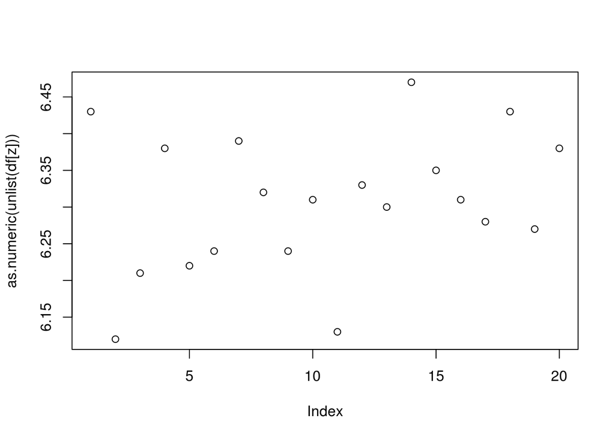

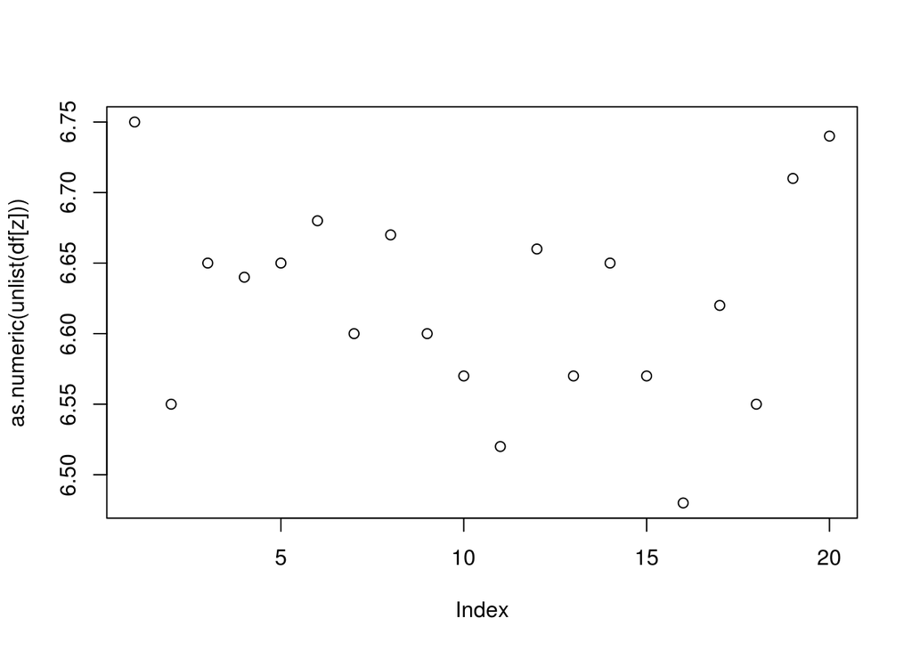

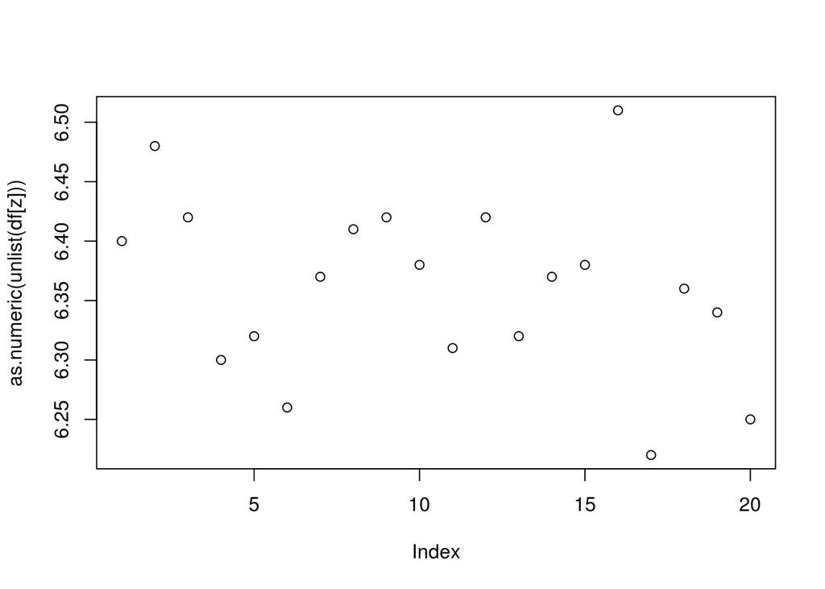

```
## average time per iteration-  1.7088  seconds
```

=============================================================================

```
## total time-  171.9  seconds
```